```python
Student: Fernanda da Silva
```

# Exercises

**Exercise 1:** Get WDI data on **patent applications by residents and non-residents in each country**. Create a new variable that shows the total patents for each country.

```python
pip install geocoder
```

[output not shown]

```python
pip install geonamescache
```

[output not shown]

[output cut: 92 more lines]

[output not shown]

```python
pip install stargazer
```

[output not shown]

```python
pip install plotnine
```

```python
# Basic Packages
from __future__ import division
import os
from datetime import datetime

# Web & file access
import requests
import io

# Import display options for showing websites
from IPython.display import IFrame, HTML

# Data Munging
from itertools import product, combinations
import difflib
import pycountry
import geocoder
from geonamescache.mappers import country
mapper = country(from_key='name', to_key='iso3')
mapper2 = country(from_key='iso3', to_key='iso')
mapper3 = country(from_key='iso3', to_key='name')

# Regressions & Stats
from scipy.stats import norm
import statsmodels.formula.api as smf
from stargazer.stargazer import Stargazer, LineLocation

import matplotlib as mpl
import matplotlib.pyplot as plt
import matplotlib.ticker as mtick

%pylab --no-import-all
%matplotlib inline

import seaborn as sns
sns.set(rc={'figure.figsize':(11.7,8.27)})
sns.set_context("talk")

import plotly.express as px
import plotly.graph_objects as go

#from plotnine import ggplot, geom_point, aes, stat_smooth, facet_wrap
```

```
Using matplotlib backend: QtAgg
%pylab is deprecated, use %matplotlib inline and import the required libraries.
```

```python
pip install pandas-datareader
```

[output not shown]

```python
import pandas as pd
import numpy as np
```

```python
# Patent of residents:
url = 'https://data.worldbank.org/indicator/IP.PAT.RESD'

from pandas_datareader import data, wb

wbcountries = wb.get_countries()

wbcountries = wb.get_countries()
wbcountries = wbcountries.loc[wbcountries.region.isin(['Aggregates'])==False].reset_index(drop=True)
wbcountries['name'] = wbcountries.name.str.strip()
wbcountries['incomeLevel'] = wbcountries['incomeLevel'].str.title()
wbcountries.loc[wbcountries.iso3c=='VEN', 'incomeLevel'] = 'Upper Middle Income'

wbcountries.head()
```

[output not shown]

[output not shown]

[output cut: 20 more lines]

[output not shown]

```
  iso3c iso2c         name                      region  \
0   ABW    AW        Aruba  Latin America & Caribbean
1   AFG    AF  Afghanistan                  South Asia
2   AGO    AO       Angola         Sub-Saharan Africa
3   ALB    AL      Albania       Europe & Central Asia
4   AND    AD      Andorra       Europe & Central Asia

                                     adminregion          incomeLevel  \
0                                                         High Income
1                                     South Asia           Low Income
2     Sub-Saharan Africa (excluding high income)  Lower Middle Income
3  Europe & Central Asia (excluding high income)  Upper Middle Income
4                                                         High Income

      lendingType       capitalCity  longitude  latitude
0  Not classified        Oranjestad   -70.0167  12.51670
1             IDA             Kabul    69.1761  34.52280
2            IBRD            Luanda    13.2420  -8.81155
3            IBRD            Tirane    19.8172  41.33170
4  Not classified  Andorra la Vella     1.5218  42.50750
```

```python
wdi_indicators = ['IP.PAT.RESD', 'IP.PAT.NRES']

list_of_countries_ISO_A2_codes=wbcountries['iso2c'].unique().tolist()
start_year='1990'
end_year='2020'

wdi = wb.download(indicator=wdi_indicators,
                  country=list_of_countries_ISO_A2_codes,
                  start=start_year,
                  end=end_year)
```

```python
wdi.columns=['Pat_resid', 'Pat_nonresid']
```

```python
wdi
```

[output not shown]

[output not shown]

[output cut: 20 more lines]

[output not shown]

```
               Pat_resid  Pat_nonresid
country  year
Aruba    2020        NaN           NaN
         2019        NaN           NaN
         2018        NaN           NaN
         2017        NaN           NaN
         2016        NaN           NaN
...                  ...           ...
Zimbabwe 1994        NaN           NaN
         1993       44.0         136.0
         1992       42.0         161.0
         1991       60.0         128.0
         1990       44.0         159.0

[6727 rows x 2 columns]
```

```python
wdi['Total_patents'] = wdi['Pat_resid'] + wdi['Pat_nonresid']
wdi
```

[output not shown]

[output not shown]

[output cut: 20 more lines]

[output not shown]

```
               Pat_resid  Pat_nonresid  Total_patents
country  year
Aruba    2020        NaN           NaN            NaN
         2019        NaN           NaN            NaN
         2018        NaN           NaN            NaN
         2017        NaN           NaN            NaN
         2016        NaN           NaN            NaN
...                  ...           ...            ...
Zimbabwe 1994        NaN           NaN            NaN
         1993       44.0         136.0          180.0
         1992       42.0         161.0          203.0
         1991       60.0         128.0          188.0
         1990       44.0         159.0          203.0

[6727 rows x 3 columns]
```

```python
wdi = wdi.reset_index()
wdi['year'] = wdi.year.astype(int)
```

```python
wdi
```

[output not shown]

[output not shown]

[output cut: 20 more lines]

[output not shown]

```
       country  year  Pat_resid  Pat_nonresid  Total_patents
0        Aruba  2020        NaN           NaN            NaN
1        Aruba  2019        NaN           NaN            NaN
2        Aruba  2018        NaN           NaN            NaN
3        Aruba  2017        NaN           NaN            NaN
4        Aruba  2016        NaN           NaN            NaN
...        ...   ...        ...           ...            ...
6722  Zimbabwe  1994        NaN           NaN            NaN
6723  Zimbabwe  1993       44.0         136.0          180.0
6724  Zimbabwe  1992       42.0         161.0          203.0
6725  Zimbabwe  1991       60.0         128.0          188.0
6726  Zimbabwe  1990       44.0         159.0          203.0

[6727 rows x 5 columns]
```

**Exercise 2:** Using the `my_xy_plot` function plot the relation between **GDP per capita** and **total patents** in the years 1990, 1995, 2000, 2010, 2020.

```python
wdi_indicators = ['NY.GDP.PCAP.PP.KD', 'NY.GDP.PCAP.KD']

wdi2 = wb.download(indicator=wdi_indicators,
                  country=list_of_countries_ISO_A2_codes,
                  start=start_year,
                  end=end_year)

wdi2 = wb.download(indicator=wdi_indicators, country=wbcountries.iso2c.values, start=1990, end=2020)
wdi2 = wdi2.reset_index()
wdi2['year'] = wdi2.year.astype(int)
wdi2['gdp_pc'] = wdi2['NY.GDP.PCAP.PP.KD']
wdi2['ln_gdp_pc'] = wdi2['NY.GDP.PCAP.PP.KD'].apply(np.log)
wdi2.head()
```

[output not shown]

[output not shown]

[output cut: 20 more lines]

[output not shown]

```
  country  year  NY.GDP.PCAP.PP.KD  NY.GDP.PCAP.KD        gdp_pc  ln_gdp_pc
0   Aruba  2020       29236.047264    23015.741867  29236.047264  10.283158
1   Aruba  2019       38511.336876    30317.606908  38511.336876  10.558708
2   Aruba  2018       39597.659876    31172.802193  39597.659876  10.586525
3   Aruba  2017       38868.333923    30598.648727  38868.333923  10.567935
4   Aruba  2016       36504.688731    28737.896241  36504.688731  10.505196
```

```python
dfin = wdi.merge(wdi2, left_on='country', right_on='country')
dfin
```

[output not shown]

[output not shown]

[output cut: 20 more lines]

[output not shown]

```
         country  year_x  Pat_resid  Pat_nonresid  Total_patents  year_y  \
0          Aruba    2020        NaN           NaN            NaN    2020
1          Aruba    2020        NaN           NaN            NaN    2019
2          Aruba    2020        NaN           NaN            NaN    2018
3          Aruba    2020        NaN           NaN            NaN    2017
4          Aruba    2020        NaN           NaN            NaN    2016
...          ...     ...        ...           ...            ...     ...
208532  Zimbabwe    1990       44.0         159.0          203.0    1994
208533  Zimbabwe    1990       44.0         159.0          203.0    1993
208534  Zimbabwe    1990       44.0         159.0          203.0    1992
208535  Zimbabwe    1990       44.0         159.0          203.0    1991
208536  Zimbabwe    1990       44.0         159.0          203.0    1990

        NY.GDP.PCAP.PP.KD  NY.GDP.PCAP.KD        gdp_pc  ln_gdp_pc
0            29236.047264    23015.741867  29236.047264  10.283158
1            38511.336876    30317.606908  38511.336876  10.558708
2            39597.659876    31172.802193  39597.659876  10.586525
3            38868.333923    30598.648727  38868.333923  10.567935
4            36504.688731    28737.896241  36504.688731  10.505196
...                   ...             ...           ...        ...
208532        2670.106615     1627.453286   2670.106615   7.889874
208533        2458.783255     1498.649854   2458.783255   7.807422
208534        2468.278257     1504.437140   2468.278257   7.811276
208535        2781.787843     1695.523970   2781.787843   7.930849
208536        2704.757299     1648.573181   2704.757299   7.902767

[208537 rows x 10 columns]
```

```python
dfin2 = dfin[dfin['year_x'] == dfin['year_y']]
dfin2 = dfin2[dfin['year_y'].isin([1990, 1995, 2000, 2005, 2010, 2015, 2020])]
dfin2 = dfin2[dfin['year_x'].isin([1990, 1995, 2000, 2005, 2010, 2015, 2020])]
dfin2 = dfin2[dfin2['country'].isin(['United States', 'Zimbabwe', 'Bhutan', 'Canada', 'Brazil'])]
dfin2
```

[output not shown]

[output not shown]

[output cut: 24 more lines]

[output not shown]

```
              country  year_x  Pat_resid  Pat_nonresid  Total_patents  year_y  \
24986          Brazil    2020     5280.0       19058.0        24338.0    2020
25146          Brazil    2015     4641.0       25578.0        30219.0    2015
25306          Brazil    2010     4228.0       20771.0        24999.0    2010
25466          Brazil    2005     4054.0       14444.0        18498.0    2005
25626          Brazil    2000     3179.0       14104.0        17283.0    2000
25786          Brazil    1995     2707.0        4741.0         7448.0    1995
25946          Brazil    1990     2389.0        5148.0         7537.0    1990
27869          Bhutan    2020        NaN           6.0            NaN    2020
28029          Bhutan    2015        1.0           7.0            8.0    2015
28189          Bhutan    2010        NaN           NaN            NaN    2010
28349          Bhutan    2005        NaN           NaN            NaN    2005
28509          Bhutan    2000        NaN           NaN            NaN    2000
28669          Bhutan    1995        NaN           NaN            NaN    1995
28829          Bhutan    1990        NaN           NaN            NaN    1990
```

[output cut: 58 more lines]

```python
def my_xy_plot(dfin,
               x='SP.POP.GROW',
               y='ln_gdp_pc',
               labelvar='iso3c',
               dx=0.006125,
               dy=0.006125,
               xlogscale=False,
               ylogscale=False,
               xlabel='Growth Rate of Population',
               ylabel='Log[Income per capita in ' +  str('year_y') + ']',
               labels=False,
               xpct = False,
               ypct = False,
               OLS=False,
               OLSlinelabel='OLS',
               ssline=False,
               sslinelabel='45 Degree Line',
               filename='income-pop-growth.pdf',
               hue='year_y',
               hue_order=[1990 , 1995, 2000, 2005, 2010 , 2015, 2020],
               style='incomeLevel',
               style_order=['High Income', 'Upper Middle Income', 'Lower Middle Income', 'Low Income'],
               palette=None,
               size=None,
               sizes=None,
               legend_fontsize=10,
               label_font_size=12,
               save=True):
    '''
    Plot the association between x and var in dataframe using labelvar for labels.
    '''
    sns.set(rc={'figure.figsize':(11.7,8.27)})
    sns.set_context("talk")
    df = dfin.copy()
    df = df.dropna(subset=[x, y]).reset_index(drop=True)
    # Plot
    k = 0
    fig, ax = plt.subplots()
    sns.scatterplot(x=x, y=y, data=df, ax=ax,
                    hue=hue,
                    hue_order=hue_order,
                    #hue='incomeLevel',
                    #hue_order=['High Income', 'Upper Middle Income', 'Lower Middle Income', 'Low Income'],
                    #hue_order=['East Asia & Pacific', 'Europe & Central Asia',
                    #           'Latin America & Caribbean ', 'Middle East & North Africa',
                    #           'North America', 'South Asia', 'Sub-Saharan Africa '],
                    alpha=1,
                    style=style,
                    style_order=style_order,
                    palette=palette,
                    size=size,
                    sizes=sizes,
                    #palette=sns.color_palette("Blues_r", df[hue].unique().shape[0]+6)[:df[hue].unique().shape[0]*2:2],
                )
    if OLS:
        sns.regplot(x=x, y=y, data=df, ax=ax, label=OLSlinelabel, scatter=False)
    if ssline:
        ax.plot([df[x].min()*.99, df[x].max()*1.01], [df[x].min()*.99, df[x].max()*1.01], c='r', label=sslinelabel)
    if labels:
        movex = df[x].mean() * dx
        movey = df[y].mean() * dy
        for line in range(0,df.shape[0]):
            ax.text(df[x][line]+movex, df[y][line]+movey, df[labelvar][line], horizontalalignment='left', fontsize=label_font_size, color='black')
    ax.set_xlabel(xlabel)
    ax.set_ylabel(ylabel)
    if xpct:
        fmt = '%.0f%%' # Format you want the ticks, e.g. '40%'
        xticks = mtick.FormatStrFormatter(fmt)
        ax.xaxis.set_major_formatter(xticks)
    if ypct:
        fmt = '%.0f%%' # Format you want the ticks, e.g. '40%'
        yticks = mtick.FormatStrFormatter(fmt)
        ax.yaxis.set_major_formatter(yticks)
    if ylogscale:
        ax.set(yscale="log")
    if xlogscale:
        ax.set(xscale="log")
    handles, labels = ax.get_legend_handles_labels()
    handles = np.array(handles)
    labels = np.array(labels)
    handles = list(handles[(labels!=hue) & (labels!=style) & (labels!=size)])
    labels = list(labels[(labels!=hue) & (labels!=style) & (labels!=size)])
    ax.legend(handles=handles, labels=labels, fontsize=legend_fontsize)
    if save:
        plt.savefig(pathgraphs + filename, dpi=300, bbox_inches='tight')
    return fig
```

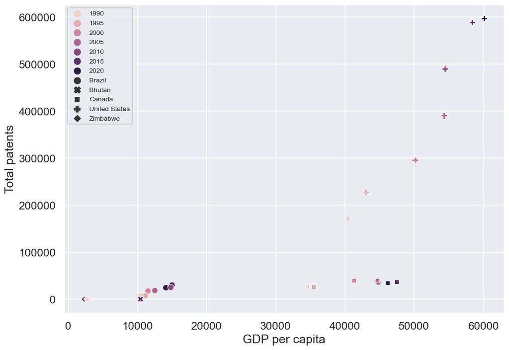

```python
fig = my_xy_plot(dfin2,
x= 'NY.GDP.PCAP.PP.KD',
y='Total_patents',
xlabel = 'GDP per capita',
ylabel = 'Total patents',
style = 'country',
style_order = dfin2['country'].unique().tolist(),
save = False)
```

**Exercise 3:** Using the `my_xy_line_plot` function plot the evolution of **GDP per capita** and **total patents** by income groups and regions (separate figures).

```python
dfin3 = dfin.merge(wbcountries, left_on='country', right_on='name')
dfin3
```

[output not shown]

[output not shown]

[output cut: 20 more lines]

[output not shown]

```
         country  year_x  Pat_resid  Pat_nonresid  Total_patents  year_y  \
0          Aruba    2020        NaN           NaN            NaN    2020
1          Aruba    2020        NaN           NaN            NaN    2019
2          Aruba    2020        NaN           NaN            NaN    2018
3          Aruba    2020        NaN           NaN            NaN    2017
4          Aruba    2020        NaN           NaN            NaN    2016
...          ...     ...        ...           ...            ...     ...
208532  Zimbabwe    1990       44.0         159.0          203.0    1994
208533  Zimbabwe    1990       44.0         159.0          203.0    1993
208534  Zimbabwe    1990       44.0         159.0          203.0    1992
208535  Zimbabwe    1990       44.0         159.0          203.0    1991
208536  Zimbabwe    1990       44.0         159.0          203.0    1990

        NY.GDP.PCAP.PP.KD  NY.GDP.PCAP.KD        gdp_pc  ln_gdp_pc iso3c  \
0            29236.047264    23015.741867  29236.047264  10.283158   ABW
```

[output cut: 51 more lines]

```python
def my_xy_line_plot(dfin3,
               x='Total_patents',
               y='gdp_pc',
               labelvar='iso3c',
               dx=0.006125,
               dy=0.006125,
               xlogscale=False,
               ylogscale=False,
               xlabel='Total Patents',
               ylabel='Income per capita',
               labels=False,
               xpct = False,
               ypct = False,
               OLS=False,
               OLSlinelabel='OLS',
               ssline=False,
               sslinelabel='45 Degree Line',
               filename='income-patent.pdf',
               hue='region',
               hue_order=['East Asia & Pacific', 'Europe & Central Asia',
                         'Latin America & Caribbean ', 'Middle East & North Africa',
                         'North America', 'South Asia', 'Sub-Saharan Africa '],
               style='incomeLevel',
               style_order=['High Income', 'Upper Middle Income', 'Lower Middle Income', 'Low Income'],
               palette=None,
               legend_fontsize=10,
               label_font_size=12,
               loc=None,
               save=True):
    '''
    Plot the association between x and var in dataframe using labelvar for labels.
    '''
    sns.set(rc={'figure.figsize':(11.7,8.27)})
    sns.set_context("talk")
    df = dfin3.copy()
    df = df.dropna(subset=[x, y]).reset_index(drop=True)
    # Plot
    k = 0
    fig, ax = plt.subplots()
    sns.lineplot(x=x, y=y, data=df, ax=ax,
                    hue=hue,
                    hue_order=hue_order,
                    alpha=1,
                    style=style,
                    style_order=style_order,
                    palette=palette,
                )
    if OLS:
        sns.regplot(x=x, y=y, data=df, ax=ax, label=OLSlinelabel, scatter=False)
    if ssline:
        ax.plot([df[x].min()*.99, df[x].max()*1.01], [df[x].min()*.99, df[x].max()*1.01], c='r', label=sslinelabel)
    if labels:
        movex = df[x].mean() * dx
        movey = df[y].mean() * dy
        for line in range(0,df.shape[0]):
            ax.text(df[x][line]+movex, df[y][line]+movey, df[labelvar][line], horizontalalignment='left', fontsize=label_fontsize, color='black')
    ax.set_xlabel(xlabel)
    ax.set_ylabel(ylabel)
    if xpct:
        fmt = '%.0f%%' # Format you want the ticks, e.g. '40%'
        xticks = mtick.FormatStrFormatter(fmt)
        ax.xaxis.set_major_formatter(xticks)
    if ypct:
        fmt = '%.0f%%' # Format you want the ticks, e.g. '40%'
        yticks = mtick.FormatStrFormatter(fmt)
        ax.yaxis.set_major_formatter(yticks)
    if ylogscale:
        ax.set(yscale="log")
    if xlogscale:
        ax.set(xscale="log")
    handles, labels = ax.get_legend_handles_labels()
    handles = np.array(handles)
    labels = np.array(labels)
    handles = list(handles[(labels!='region') & (labels!='incomeLevel')])
    labels = list(labels[(labels!='region') & (labels!='incomeLevel')])
    ax.legend(handles=handles, labels=labels, fontsize=legend_fontsize, loc=loc)
    if save:
        plt.savefig(pathgraphs + filename, dpi=300, bbox_inches='tight')
    return fig
```

```python
dfin4 = dfin3[dfin3['year_x'] == dfin3['year_y']]
dfin4 = dfin4[dfin3['year_y'].isin([1990, 1995, 2000, 2005, 2010, 2015, 2020])]
dfin4 = dfin4[dfin3['year_x'].isin([1990, 1995, 2000, 2005, 2010, 2015, 2020])]
dfin4 = dfin4[dfin4['region'].isin(['East Asia & Pacific', 'Europe & Central Asia',
                                   'Latin America & Caribbean ', 'Middle East & North Africa',
                                   'North America', 'South Asia', 'Sub-Saharan Africa '])]
dfin4
```

[output not shown]

[output not shown]

[output cut: 24 more lines]

[output not shown]

```
         country  year_x  Pat_resid  Pat_nonresid  Total_patents  year_y  \
0          Aruba    2020        NaN           NaN            NaN    2020
160        Aruba    2015        NaN           NaN            NaN    2015
320        Aruba    2010        NaN           NaN            NaN    2010
480        Aruba    2005        NaN           NaN            NaN    2005
640        Aruba    2000        NaN           NaN            NaN    2000
...          ...     ...        ...           ...            ...     ...
207896  Zimbabwe    2010        NaN           NaN            NaN    2010
208056  Zimbabwe    2005        NaN           NaN            NaN    2005
208216  Zimbabwe    2000        NaN           NaN            NaN    2000
208376  Zimbabwe    1995       55.0         125.0          180.0    1995
208536  Zimbabwe    1990       44.0         159.0          203.0    1990

        NY.GDP.PCAP.PP.KD  NY.GDP.PCAP.KD        gdp_pc  ln_gdp_pc iso3c  \
0            29236.047264    23015.741867  29236.047264  10.283158   ABW
```

[output cut: 51 more lines]

```python
import os

# Define folder paths
path = './data/'
pathout = './data/'
pathgraphs = './graphs/'

# Check if the folders exist, if not, create them
if not os.path.exists(path):
    os.makedirs(path)

if not os.path.exists(pathout):
    os.makedirs(pathout)

if not os.path.exists(pathgraphs):
    os.makedirs(pathgraphs)
```

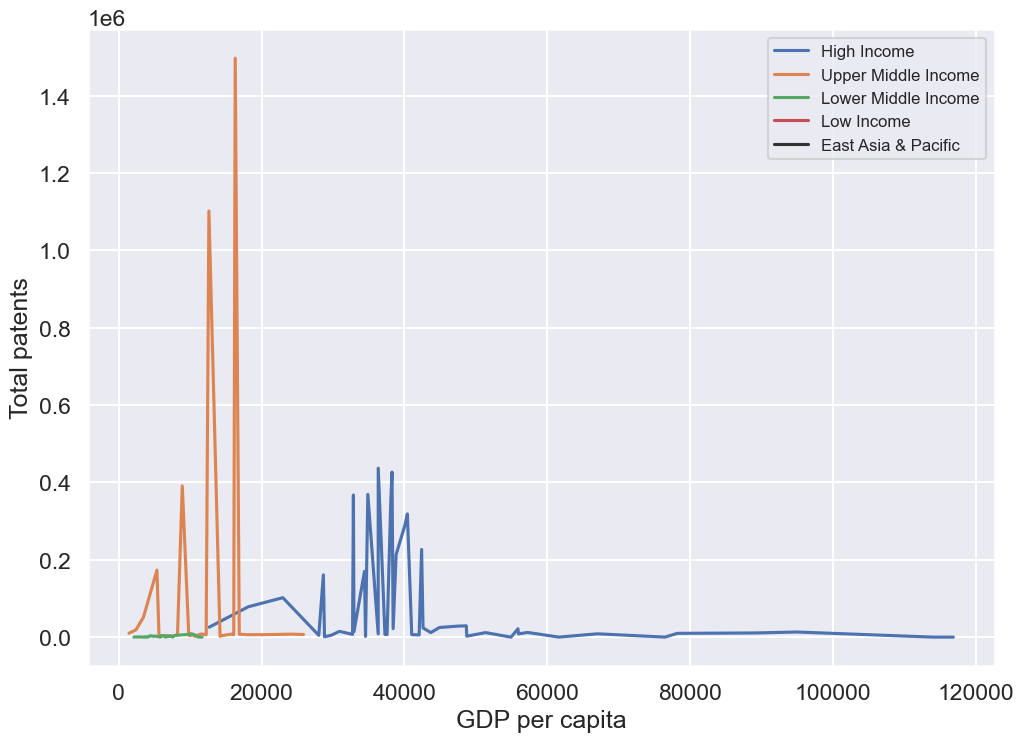

```python
dfin5 = dfin4[dfin4['year_x'] == dfin4['year_y']]
dfin5 = dfin5[dfin4['year_y'].isin([1990, 1995, 2000, 2005, 2010, 2015, 2020])]
dfin5 = dfin5[dfin4['year_x'].isin([1990, 1995, 2000, 2005, 2010, 2015, 2020])]
dfin5 = dfin5[dfin5['region'].isin(['East Asia & Pacific'])]

fig = my_xy_line_plot(dfin5,
                      x= 'NY.GDP.PCAP.PP.KD',
                      y='Total_patents',
                      xlabel = 'GDP per capita',
                      ylabel = 'Total patents',
                      hue='incomeLevel',
                      hue_order=['High Income', 'Upper Middle Income', 'Lower Middle Income', 'Low Income'],
                      style = 'region',
                      style_order = dfin5['region'].unique().tolist(),
                      OLS=False,
                      labels=False,
                      legend_fontsize=12,
                      save=True)
```

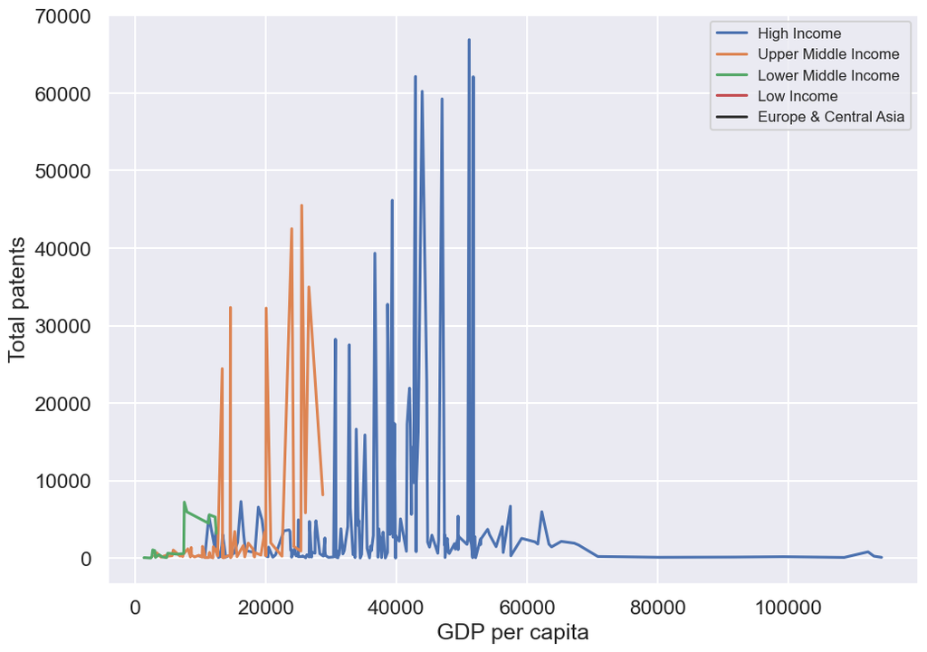

```python
dfin6 = dfin4[dfin4['year_x'] == dfin4['year_y']]
dfin6 = dfin6[dfin4['year_y'].isin([1990, 1995, 2000, 2005, 2010, 2015, 2020])]
dfin6 = dfin6[dfin4['year_x'].isin([1990, 1995, 2000, 2005, 2010, 2015, 2020])]
dfin6 = dfin6[dfin6['region'].isin(['Europe & Central Asia'])]

fig = my_xy_line_plot(dfin6,
                      x= 'NY.GDP.PCAP.PP.KD',
                      y='Total_patents',
                      xlabel = 'GDP per capita',
                      ylabel = 'Total patents',
                      hue='incomeLevel',
                      hue_order=['High Income', 'Upper Middle Income', 'Lower Middle Income', 'Low Income'],
                      style = 'region',
                      style_order = dfin6['region'].unique().tolist(),
                      OLS=False,
                      labels=False,
                      legend_fontsize=12,
                      save=True)
```

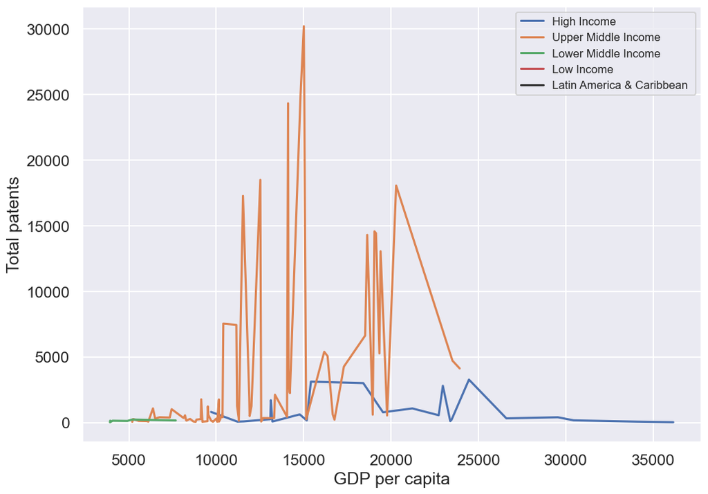

```python
dfin7 = dfin4[dfin4['year_x'] == dfin4['year_y']]
dfin7 = dfin7[dfin4['year_y'].isin([1990, 1995, 2000, 2005, 2010, 2015, 2020])]
dfin7 = dfin7[dfin4['year_x'].isin([1990, 1995, 2000, 2005, 2010, 2015, 2020])]
dfin7 = dfin7[dfin7['region'].isin(['Latin America & Caribbean '])]

fig = my_xy_line_plot(dfin7,
                      x= 'NY.GDP.PCAP.PP.KD',
                      y='Total_patents',
                      xlabel = 'GDP per capita',
                      ylabel = 'Total patents',
                      hue='incomeLevel',
                      hue_order=['High Income', 'Upper Middle Income', 'Lower Middle Income', 'Low Income'],
                      style = 'region',
                      style_order = dfin7['region'].unique().tolist(),
                      OLS=False,
                      labels=False,
                      legend_fontsize=12,
                      save=True)
```

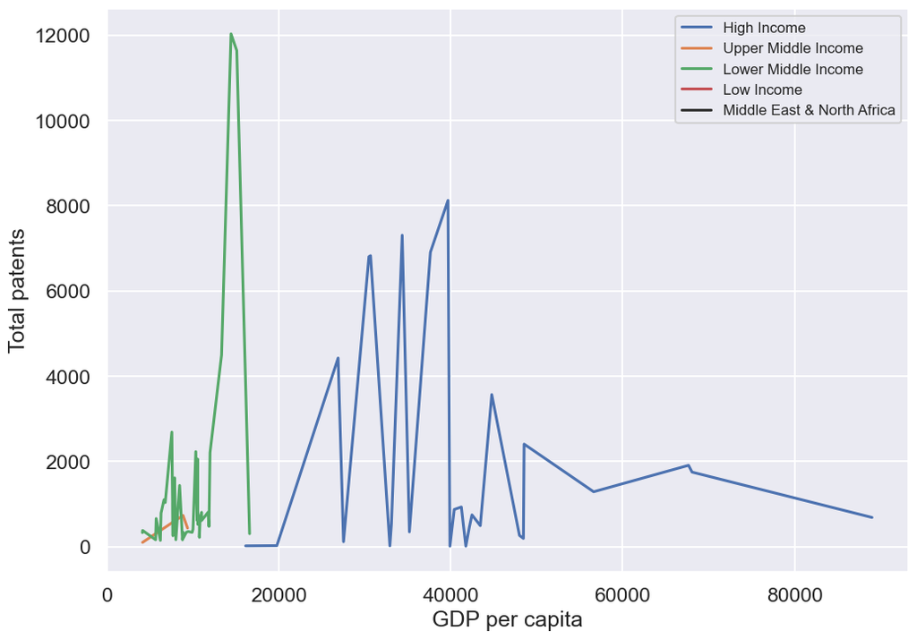

```python
dfin8 = dfin4[dfin4['year_x'] == dfin4['year_y']]
dfin8 = dfin8[dfin4['year_y'].isin([1990, 1995, 2000, 2005, 2010, 2015, 2020])]
dfin8 = dfin8[dfin4['year_x'].isin([1990, 1995, 2000, 2005, 2010, 2015, 2020])]
dfin8 = dfin8[dfin8['region'].isin(['Middle East & North Africa'])]

fig = my_xy_line_plot(dfin8,
                      x= 'NY.GDP.PCAP.PP.KD',
                      y='Total_patents',
                      xlabel = 'GDP per capita',
                      ylabel = 'Total patents',
                      hue='incomeLevel',
                      hue_order=['High Income', 'Upper Middle Income', 'Lower Middle Income', 'Low Income'],
                      style = 'region',
                      style_order = dfin8['region'].unique().tolist(),
                      OLS=False,
                      labels=False,
                      legend_fontsize=12,
                      save=True)
```

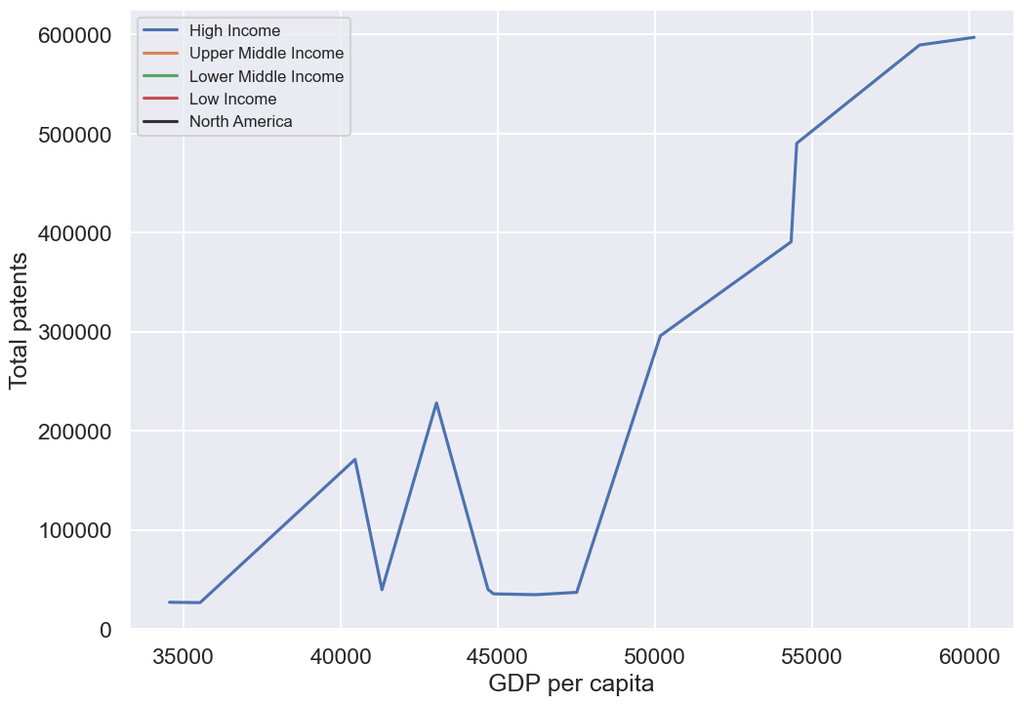

```python
dfin9 = dfin4[dfin4['year_x'] == dfin4['year_y']]
dfin9 = dfin9[dfin4['year_y'].isin([1990, 1995, 2000, 2005, 2010, 2015, 2020])]
dfin9 = dfin9[dfin4['year_x'].isin([1990, 1995, 2000, 2005, 2010, 2015, 2020])]
dfin9 = dfin9[dfin9['region'].isin(['North America'])]

fig = my_xy_line_plot(dfin9,
                      x= 'NY.GDP.PCAP.PP.KD',
                      y='Total_patents',
                      xlabel = 'GDP per capita',
                      ylabel = 'Total patents',
                      hue='incomeLevel',
                      hue_order=['High Income', 'Upper Middle Income', 'Lower Middle Income', 'Low Income'],
                      style = 'region',
                      style_order = dfin9['region'].unique().tolist(),
                      OLS=False,
                      labels=False,
                      legend_fontsize=12,
                      save=True)
```

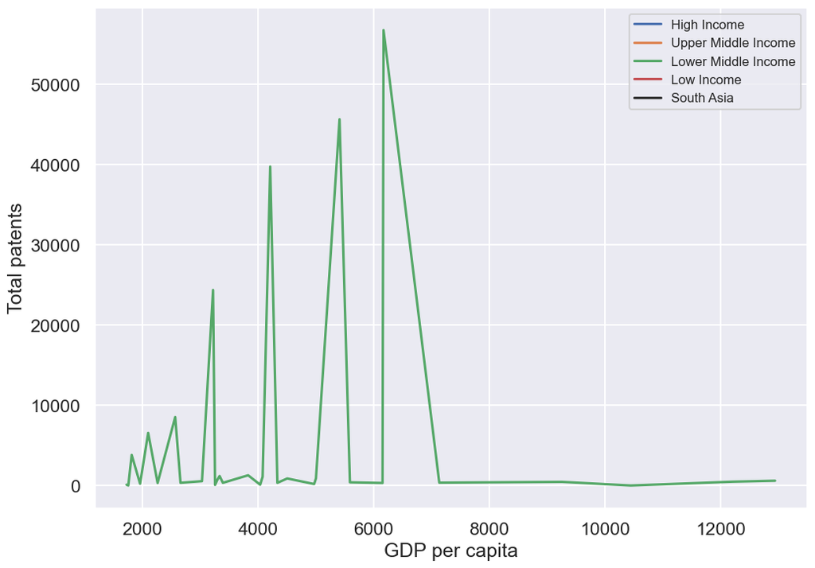

```python
dfin10 = dfin4[dfin4['year_x'] == dfin4['year_y']]
dfin10 = dfin10[dfin4['year_y'].isin([1990, 1995, 2000, 2005, 2010, 2015, 2020])]
dfin10 = dfin10[dfin4['year_x'].isin([1990, 1995, 2000, 2005, 2010, 2015, 2020])]
dfin10 = dfin10[dfin10['region'].isin(['South Asia'])]

fig = my_xy_line_plot(dfin10,
                      x= 'NY.GDP.PCAP.PP.KD',
                      y='Total_patents',
                      xlabel = 'GDP per capita',
                      ylabel = 'Total patents',
                      hue='incomeLevel',
                      hue_order=['High Income', 'Upper Middle Income', 'Lower Middle Income', 'Low Income'],
                      style = 'region',
                      style_order = dfin10['region'].unique().tolist(),
                      OLS=False,
                      labels=False,
                      legend_fontsize=12,
                      save=True)
```

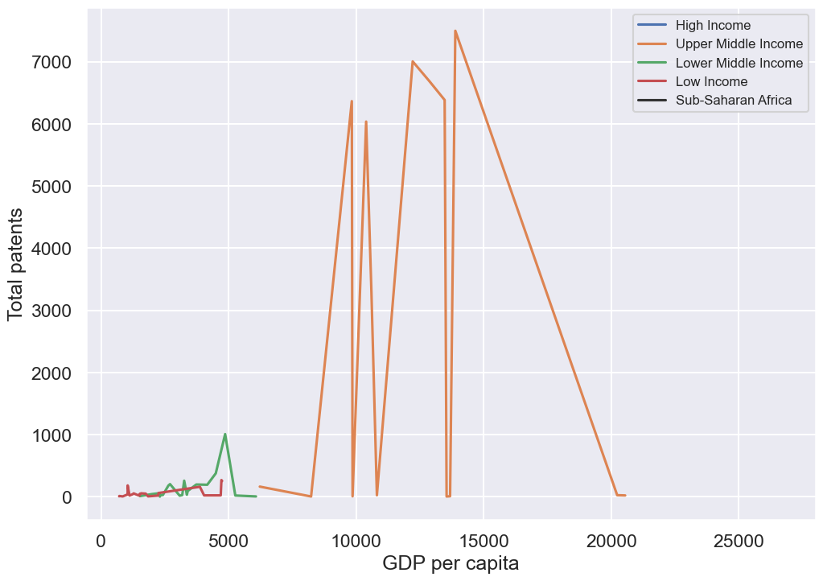

```python
dfin11 = dfin4[dfin4['year_x'] == dfin4['year_y']]
dfin11 = dfin11[dfin4['year_y'].isin([1990, 1995, 2000, 2005, 2010, 2015, 2020])]
dfin11 = dfin11[dfin4['year_x'].isin([1990, 1995, 2000, 2005, 2010, 2015, 2020])]
dfin11 = dfin11[dfin11['region'].isin(['Sub-Saharan Africa '])]

fig = my_xy_line_plot(dfin11,
                      x= 'NY.GDP.PCAP.PP.KD',
                      y='Total_patents',
                      xlabel = 'GDP per capita',
                      ylabel = 'Total patents',
                      hue='incomeLevel',
                      hue_order=['High Income', 'Upper Middle Income', 'Lower Middle Income', 'Low Income'],
                      style = 'region',
                      style_order = dfin11['region'].unique().tolist(),
                      OLS=False,
                      labels=False,
                      legend_fontsize=12,
                      save=True)
```

**Exercise 4:** Plot the relation between patenting activity by **residents and non-residents** in the year 2015. Make sure to show the 45 degree line so you can see how similar they are.

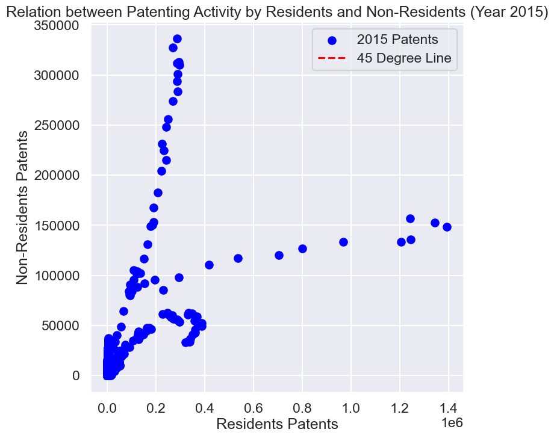

```python
# Plotting the scatter plot
df_2015 = dfin[dfin['year_y'] == 2015]

# Plotting
plt.figure(figsize=(8, 8))
plt.scatter(df_2015['Pat_resid'], df_2015['Pat_nonresid'], color='blue', label='2015 Patents')
plt.plot([0, max(df_2015['Pat_resid'])], [0, max(df_2015['Pat_resid'])], color='red', linestyle='--', label='45 Degree Line')
plt.xlabel('Residents Patents')
plt.ylabel('Non-Residents Patents')
plt.title('Relation between Patenting Activity by Residents and Non-Residents (Year 2015)')
plt.legend()
plt.grid(True)
plt.show()
```

**Exercise 5:** Create a static and a dynamic map for patenting activity in the year 2015 across the world.

```python
pip install geopandas
```

[output not shown]

```python
import geopandas as gpd
import matplotlib.pyplot as plt
```

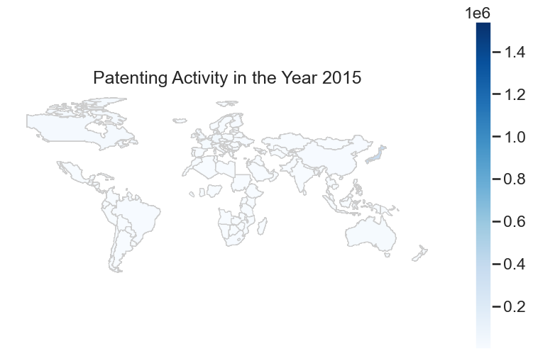

```python
#Static map
world = gpd.read_file(gpd.datasets.get_path('naturalearth_lowres'))
worldpatent = world.merge(df_2015, how='left', left_on='name', right_on='country')

fig, ax = plt.subplots(1, 1, figsize=(10, 6))
worldpatent.plot(column='Total_patents', cmap='Blues', linewidth=0.8, ax=ax, edgecolor='0.8', legend=True)
ax.axis('off')
plt.title('Patenting Activity in the Year 2015')
plt.show()
```

```python
pip install folium
```

[output not shown]

```python
#Dynamic map

import folium

# Create a base map
map = folium.Map(location=[30, 0], zoom_start=2)

# Add choropleth layer for patenting activity
folium.Choropleth(
    geo_data=world,
    name='choropleth',
    data=df_2015,
    columns=['country', 'Total_patents'],
    key_on='feature.properties.name',
    fill_color='YlGn',
    fill_opacity=0.7,
    line_opacity=0.2,
    legend_name='Patents 2015'
).add_to(map)

# Display the map
map.save('patenting_activity_2015.html')
map
```

Make this Notebook Trusted to load map: File -> Trust Notebook

[interactive chart not shown]

**Exercise 6:** Explore the relation between economic development as measured by Log[GDP per capita] and patenting activity. Show the relation for residents, non-residents, and total, all in one nice looking table. Also, produce a few nice looking figures.

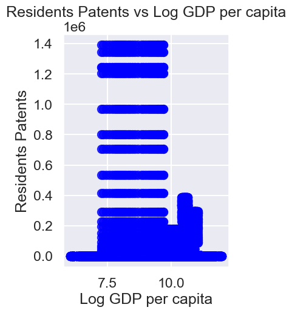

```python
# Plot GDP per capita vs Residents Patents
plt.figure(figsize=(12, 5))
plt.subplot(1, 3, 1)
sns.regplot(x='ln_gdp_pc', y='Pat_resid', data=dfin, scatter_kws={'s': 100}, color='blue')
plt.title('Residents Patents vs Log GDP per capita')
plt.xlabel('Log GDP per capita')
plt.ylabel('Residents Patents')
```

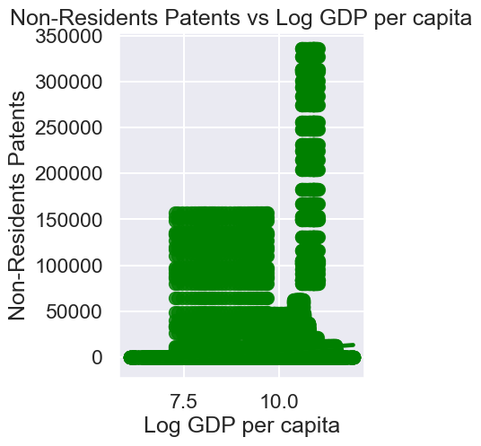

```python
# Plot GDP per capita vs Non-Residents Patents
plt.figure(figsize=(12, 5))
plt.subplot(1, 3, 2)
sns.regplot(x='ln_gdp_pc', y='Pat_nonresid', data=dfin, scatter_kws={'s': 100}, color='green')
plt.title('Non-Residents Patents vs Log GDP per capita')
plt.xlabel('Log GDP per capita')
plt.ylabel('Non-Residents Patents')
```

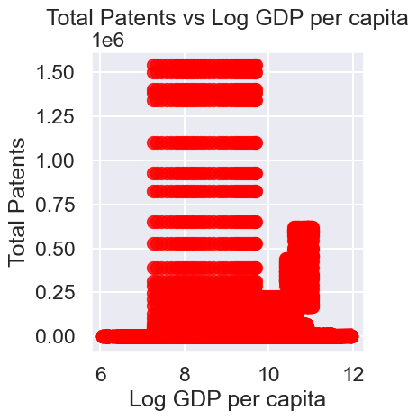

```python
# Plot GDP per capita vs Total Patents
plt.figure(figsize=(12, 5))
plt.subplot(1, 3, 3)
sns.regplot(x='ln_gdp_pc', y='Total_patents', data=dfin, scatter_kws={'s': 100}, color='red')
plt.title('Total Patents vs Log GDP per capita')
plt.xlabel('Log GDP per capita')
plt.ylabel('Total Patents')

plt.tight_layout()
plt.show()
```

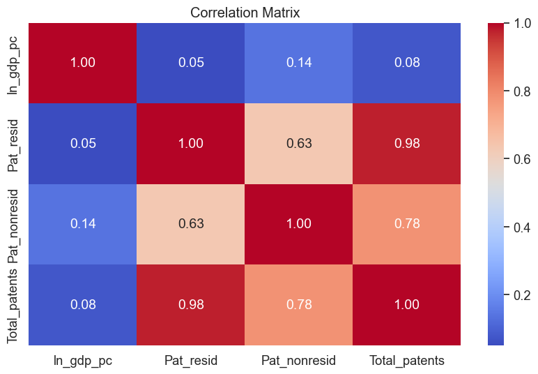

```python
# Create a nice looking table
plt.figure(figsize=(10, 6))
sns.set(font_scale=1.2)  # Set font scale
sns.heatmap(dfin[['ln_gdp_pc', 'Pat_resid', 'Pat_nonresid', 'Total_patents']].corr(),
            annot=True, cmap='coolwarm', fmt=".2f", annot_kws={"size": 14})
plt.title('Correlation Matrix')
plt.show()
```

[figure not shown]